# NBA dataset

Gonzalo Rodríguez

24/10/2020

## Objetivo del trabajo

Responder las siguientes preguntas ¿Hay una fuerte relación entre los datos de los jugadores y sus salarios? La respuesta es absolutamente sí, pero ¿cuánto?

## Descripción de las variables

En primer lugar es importante conocer el dataset que tenemos en tre manos por ello se explicarán las variables de la base de datos:

**Player**: son el nombre y apellido del jugador

**Salary**: Es el salario que percibe el jugador

**NBA_Country** : Es el país de procedencia del jugador

**NBA_DraftNumber**:El número en el que el jugador fue drafteado

**Age**: Es la edad del jugador

**Tm**:Equipo para el juega

**G**: Número de partidos jugados

**MP**: Minutos jugados

**PER**: El PER es una estadística avanzada usada en la NBA, para medir el rendimiento de un jugador la media es 15

**TS%**: tanto por ciento de tiros acertados

**3PAr** : Tasa de Intento de 3 puntos Porcentaje

**FTr** : Tasa de intentos de lanzamiento libre Número de intentos FT por intento FG

**ORB%**: Porcentaje de rebote ofensivo Una estimación del porcentaje de rebotes ofensivos disponibles que un jugador agarró mientras estaba en el suelo.

**DRB%** : Porcentaje de rebote defensivo Una estimación del porcentaje de rebotes defensivos disponibles que un jugador agarró mientras estaba en el suelo.

**TRB%** : Porcentaje de rebote total Estimación del porcentaje de rebotes disponibles que un jugador agarró mientras estaba en el suelo.

**AST**:Porcentaje de asistencia. Estimación del porcentaje de canastas de campo de un compañero de equipo que un jugador asistió mientras estaba en la pista.

**STL%**:Porcentaje de robo. Una estimación del porcentaje de posesiones del oponente que terminan con un robo por parte del jugador mientras estaba en la pista

**BLK**:Porcentaje de tapón.

Una estimación del porcentaje de intentos de canasta de dos puntos del oponente bloqueados por el jugador mientras estaba en la pista.

**TOV%**: Porcentaje de pérdidas por cada 100 posesiones.

**USG**: Porcentaje de uso. Una estimación del porcentaje de jugadas en equipo utilizadas por un jugador mientras estaba en el suelo.

**OWS**: Acciones de Ganancias Ofensivas Una estimación del número de ganancias aportadas por un jugador debido a su ataque.

**DWS**:Acciones de victoria defensiva. Estimación del número de victorias aportadas por un jugador debido a su defensa.

**WS**:Acciones ganadoras Una estimación del número de ganancias aportadas por un jugador.

**WS/48**: Acciones de victoria por 48 minutos. Una estimación del número de victorias aportadas por un jugador por 48 minutos (el promedio de la liga es aproximadamente .100)

**OBPM**:Cuadro ofensivo más/menos. Un cálculo de los puntos ofensivos por cada 100 posesiones que un jugador aportó por encima del promedio de la liga, traducido a un equipo promedio.

**DBPM**: Caja defensiva más/menos. Una estimación de la puntuación de caja de los puntos defensivos por cada 100 posesiones que un jugador aportó por encima del promedio de un jugador de la liga, traducido a un equipo promedio.

**BPM**:Caja Más/Menos Una estimación de la puntuación de caja de los puntos por cada 100 posesiones que un jugador aportó por encima del promedio de un jugador de la liga, traducido a un equipo promedio.

**VORP**: Valor sobre el jugador de reemplazo Una estimación de la puntuación de caja de los puntos por cada 100 posesiones del equipo que un jugador contribuyó por encima del nivel de reemplazo (-2.0), traducido a un equipo promedio y prorrateado a una temporada de 82 juegos.

## Cargamos la tabla y las librerías de necesarias.

- Procesamiento de los datos

Miramos los valores únicos de cada fila

```
## # A tibble: 485 x 28
##    Player Salary NBA_Country NBA_DraftNumber   Age Tm        G    MP   PER `TS%`
##    <chr>   <dbl> <chr>                 <dbl> <dbl> <chr> <dbl> <dbl> <dbl> <dbl>
##  1 Zhou ~ 8.16e5 China                    43    22 HOU      16    87   0.6 0.303
##  2 Zaza ~ 3.48e6 Georgia                  42    33 GSW      66   937  16.8 0.608
##  3 Zach ~ 1.23e7 USA                      19    36 SAC      59  1508  17.3 0.529
##  4 Zach ~ 3.20e6 USA                      13    22 CHI      24   656  14.6 0.499
##  5 Zach ~ 3.06e6 USA                      10    20 POR      62   979   8.2 0.487
##  6 Yogi ~ 1.31e6 USA                      62    24 DAL      79  2238  11.5 0.543
##  7 Xavie~ 7.42e4 USA                      62    30 BOS       2     7  -4.9 0
##  8 Xavie~ 4.61e4 Canada                   62    23 MEM       5   118   0.9 0.315
##  9 Wilso~ 1.20e7 USA                      23    30 DEN      70  2200  11.1 0.543
## 10 Willy~ 1.44e6 Spain                    35    23 TOT      45   430  20.6 0.592
## # ... with 475 more rows, and 18 more variables: `3PAr` <dbl>, FTr <dbl>,
## #   `ORB%` <dbl>, `DRB%` <dbl>, `TRB%` <dbl>, `AST%` <dbl>, `STL%` <dbl>,
## #   `BLK%` <dbl>, `TOV%` <dbl>, `USG%` <dbl>, OWS <dbl>, DWS <dbl>, WS <dbl>,
## #   `WS/48` <dbl>, OBPM <dbl>, DBPM <dbl>, BPM <dbl>, VORP <dbl>
```

Miramos los únicos de columna player, para ver como se estructura.

```
## # A tibble: 483 x 1
##    `NBA_dataset$Player`
##    <chr>
##  1 Zhou Qi
##  2 Zaza Pachulia
##  3 Zach Randolph
##  4 Zach LaVine
##  5 Zach Collins
##  6 Yogi Ferrell
##  7 Xavier Silas
##  8 Xavier Rathan-Mayes
##  9 Wilson Chandler
## 10 Willy Hernangomez
## # ... with 473 more rows
```

- Contamos el número de jugadores duplicados que tenemos en nuestro conjunto de datos

[output not shown]

[output cut: 26 more lines]

```
## [1] 2
```

Al hacer un conteo de números de jugadores repetidos y observamos que hay 2 repetidos.

- Se eliminan y se guardan los datos.

```
## # A tibble: 483 x 28
##    Player Salary NBA_Country NBA_DraftNumber   Age Tm        G    MP   PER `TS%`
##    <chr>   <dbl> <chr>                 <dbl> <dbl> <chr> <dbl> <dbl> <dbl> <dbl>
##  1 Zhou ~ 8.16e5 China                    43    22 HOU      16    87   0.6 0.303
##  2 Zaza ~ 3.48e6 Georgia                  42    33 GSW      66   937  16.8 0.608
##  3 Zach ~ 1.23e7 USA                      19    36 SAC      59  1508  17.3 0.529
##  4 Zach ~ 3.20e6 USA                      13    22 CHI      24   656  14.6 0.499
##  5 Zach ~ 3.06e6 USA                      10    20 POR      62   979   8.2 0.487
##  6 Yogi ~ 1.31e6 USA                      62    24 DAL      79  2238  11.5 0.543
##  7 Xavie~ 7.42e4 USA                      62    30 BOS       2     7  -4.9 0
##  8 Xavie~ 4.61e4 Canada                   62    23 MEM       5   118   0.9 0.315
##  9 Wilso~ 1.20e7 USA                      23    30 DEN      70  2200  11.1 0.543
## 10 Willy~ 1.44e6 Spain                    35    23 TOT      45   430  20.6 0.592
## # ... with 473 more rows, and 18 more variables: `3PAr` <dbl>, FTr <dbl>,
## #   `ORB%` <dbl>, `DRB%` <dbl>, `TRB%` <dbl>, `AST%` <dbl>, `STL%` <dbl>,
## #   `BLK%` <dbl>, `TOV%` <dbl>, `USG%` <dbl>, OWS <dbl>, DWS <dbl>, WS <dbl>,
## #   `WS/48` <dbl>, OBPM <dbl>, DBPM <dbl>, BPM <dbl>, VORP <dbl>
```

```
## [1] 0
```

Contamos de nuevo y comprobamos que ahora no hay duplicados.

- Antes de realizar el modelo lineal, es necesario cambiar el nombre a alguna de las columnas de nuestro conjunto de datos.

*A continuación se muestra el nombre de las columnas*.

```
##  [1] "Player"          "Salary"          "NBA_Country"     "NBA_DraftNumber"
##  [5] "Age"             "Tm"              "G"               "MP"
##  [9] "PER"             "TS_"             "threePAr"        "FTr"
## [13] "ORB_"            "DRB_"            "TRB_"            "AST_"
## [17] "STL_"            "BLK_"            "TOV_"            "USG_"
## [21] "OWS"             "DWS"             "WS"              "WS_48"
## [25] "OBPM"            "DBPM"            "BPM"             "VORP"
```

Realizamos la regresión lineal de las variables y observamos cuales son las significativas

```
##
## Call:
## lm(formula = Salary ~ Age + PER + ORB_ + STL_ + OWS + OBPM +
##     TS_ + DRB_ + BLK_ + DWS + DBPM + G + threePAr + TRB_ + TOV_ +
##     WS + BPM + NBA_DraftNumber + MP + FTr + AST_ + USG_ + WS_48 +
##     VORP, data = NBA_dataset)
##
## Residuals:
##       Min        1Q    Median        3Q       Max
## -15354874  -3000738   -385019   2114291  21684587
##
## Coefficients:
##                 Estimate Std. Error t value Pr(>|t|)
## (Intercept)     -2257549    4909948  -0.460    0.646
## Age               517569      56727   9.124  < 2e-16 ***
## PER              -353478     281293  -1.257    0.210
## ORB_            -1067597     906856  -1.177    0.240
## STL_             -194112     423061  -0.459    0.647
## OWS             -1323605    4518535  -0.293    0.770
## OBPM             1935687    4772501   0.406    0.685
## TS_             -2184162    5160879  -0.423    0.672
## DRB_             -868491     897793  -0.967    0.334
## BLK_              110027     318948   0.345    0.730
## DWS             -1790690    4544903  -0.394    0.694
## DBPM             1494922    4687825   0.319    0.750
## G                -154422      25036  -6.168 1.53e-09 ***
## threePAr        -3441403    2364332  -1.456    0.146
## TRB_             2033598    1797209   1.132    0.258
## TOV_                4106      52808   0.078    0.938
## WS               1877630    4523606   0.415    0.678
## BPM             -1353095    4705755  -0.288    0.774
## NBA_DraftNumber   -60665      12807  -4.737 2.90e-06 ***
## MP                  5670       1087   5.217 2.76e-07 ***
## FTr              -151800     889330  -0.171    0.865
## AST_              -19939      47665  -0.418    0.676
## USG_              167442     105277   1.590    0.112
## WS_48            1893689   11822704   0.160    0.873
## VORP              632085     635260   0.995    0.320
## ---
## Signif. codes:  0 '***' 0.001 '**' 0.01 '*' 0.05 '.' 0.1 ' ' 1
##
## Residual standard error: 5114000 on 456 degrees of freedom
##   (2 observations deleted due to missingness)
## Multiple R-squared:  0.5469, Adjusted R-squared:  0.5231
## F-statistic: 22.94 on 24 and 456 DF,  p-value: < 2.2e-16
```

Vemos que hay *cuatro variables* significativas,la *edad*, el *número del draft*, el *número de partidos jugados* y los *minutos por partido jugados*.

- Validación Global del modelo

```
##
## Call:
## lm(formula = Salary ~ Age + PER + ORB_ + STL_ + OWS + OBPM +
##     TS_ + DRB_ + BLK_ + DWS + DBPM + G + threePAr + TRB_ + TOV_ +
##     WS + BPM + NBA_DraftNumber + MP + FTr + AST_ + USG_ + WS_48 +
##     VORP, data = NBA_dataset)
##
## Residuals:
##       Min        1Q    Median        3Q       Max
## -15354874  -3000738   -385019   2114291  21684587
##
## Coefficients:
##                 Estimate Std. Error t value Pr(>|t|)
## (Intercept)     -2257549    4909948  -0.460    0.646
## Age               517569      56727   9.124  < 2e-16 ***
## PER              -353478     281293  -1.257    0.210
## ORB_            -1067597     906856  -1.177    0.240
## STL_             -194112     423061  -0.459    0.647
## OWS             -1323605    4518535  -0.293    0.770
## OBPM             1935687    4772501   0.406    0.685
## TS_             -2184162    5160879  -0.423    0.672
## DRB_             -868491     897793  -0.967    0.334
## BLK_              110027     318948   0.345    0.730
## DWS             -1790690    4544903  -0.394    0.694
## DBPM             1494922    4687825   0.319    0.750
## G                -154422      25036  -6.168 1.53e-09 ***
## threePAr        -3441403    2364332  -1.456    0.146
## TRB_             2033598    1797209   1.132    0.258
## TOV_                4106      52808   0.078    0.938
## WS               1877630    4523606   0.415    0.678
## BPM             -1353095    4705755  -0.288    0.774
## NBA_DraftNumber   -60665      12807  -4.737 2.90e-06 ***
## MP                  5670       1087   5.217 2.76e-07 ***
## FTr              -151800     889330  -0.171    0.865
## AST_              -19939      47665  -0.418    0.676
## USG_              167442     105277   1.590    0.112
## WS_48            1893689   11822704   0.160    0.873
## VORP              632085     635260   0.995    0.320
## ---
## Signif. codes:  0 '***' 0.001 '**' 0.01 '*' 0.05 '.' 0.1 ' ' 1
##
## Residual standard error: 5114000 on 456 degrees of freedom
##   (2 observations deleted due to missingness)
## Multiple R-squared:  0.5469, Adjusted R-squared:  0.5231
## F-statistic: 22.94 on 24 and 456 DF,  p-value: < 2.2e-16
##
##
## ASSESSMENT OF THE LINEAR MODEL ASSUMPTIONS
## USING THE GLOBAL TEST ON 4 DEGREES-OF-FREEDOM:
## Level of Significance =  0.05
##
## Call:
##  gvlma(x = regresion)
##
##                       Value   p-value                   Decision
## Global Stat        115.6519 0.000e+00 Assumptions NOT satisfied!
## Skewness            32.2341 1.367e-08 Assumptions NOT satisfied!
## Kurtosis            50.9726 9.366e-13 Assumptions NOT satisfied!
## Link Function       31.9115 1.614e-08 Assumptions NOT satisfied!
## Heteroscedasticity   0.5336 4.651e-01    Assumptions acceptable.
```

Se observa que únicamente solo se cumple la *Heterostacidad*, no obstante esto no influye en nuestro modelo predictivo

- Modelo AIC

Que nos da la combinación óptima de variables predictoras óptimas, la cual es la que *menor AIC* tiene.

```
## Start:  AIC=14884.83
## Salary ~ Age + PER + ORB_ + STL_ + OWS + OBPM + TS_ + DRB_ +
##     BLK_ + DWS + DBPM + G + threePAr + TRB_ + TOV_ + WS + BPM +
##     NBA_DraftNumber + MP + FTr + AST_ + USG_ + WS_48 + VORP
##
##                   Df  Sum of Sq        RSS   AIC
## - TOV_             1 1.5809e+11 1.1926e+16 14883
## - WS_48            1 6.7100e+11 1.1927e+16 14883
## - FTr              1 7.6200e+11 1.1927e+16 14883
## - BPM              1 2.1624e+12 1.1928e+16 14883
## - OWS              1 2.2442e+12 1.1928e+16 14883
## - DBPM             1 2.6597e+12 1.1929e+16 14883
## - BLK_             1 3.1124e+12 1.1929e+16 14883
## - DWS              1 4.0600e+12 1.1930e+16 14883
## - OBPM             1 4.3025e+12 1.1931e+16 14883
## - WS               1 4.5060e+12 1.1931e+16 14883
## - AST_             1 4.5768e+12 1.1931e+16 14883
## - TS_              1 4.6845e+12 1.1931e+16 14883
## - STL_             1 5.5060e+12 1.1932e+16 14883
## - DRB_             1 2.4475e+13 1.1951e+16 14884
## - VORP             1 2.5893e+13 1.1952e+16 14884
## - TRB_             1 3.3487e+13 1.1960e+16 14884
## - ORB_             1 3.6247e+13 1.1962e+16 14884
## - PER              1 4.1299e+13 1.1968e+16 14884
## <none>                          1.1926e+16 14885
## - threePAr         1 5.5411e+13 1.1982e+16 14885
## - USG_             1 6.6161e+13 1.1992e+16 14886
## - NBA_DraftNumber  1 5.8685e+14 1.2513e+16 14906
## - MP               1 7.1197e+14 1.2638e+16 14911
## - G                1 9.9498e+14 1.2921e+16 14921
## - Age              1 2.1772e+15 1.4103e+16 14964
##
## Step:  AIC=14882.84
## Salary ~ Age + PER + ORB_ + STL_ + OWS + OBPM + TS_ + DRB_ +
##     BLK_ + DWS + DBPM + G + threePAr + TRB_ + WS + BPM + NBA_DraftNumber +
##     MP + FTr + AST_ + USG_ + WS_48 + VORP
##
##                   Df  Sum of Sq        RSS   AIC
## - FTr              1 7.3100e+11 1.1927e+16 14881
## - WS_48            1 8.2601e+11 1.1927e+16 14881
```

[output cut: 387 more lines]

```
## + WS_48            1 1.3370e+11 1.2042e+16 14866
## + OWS              1 6.4951e+10 1.2042e+16 14866
## + TOV_             1 5.1403e+10 1.2042e+16 14866
## + STL_             1 1.2172e+10 1.2042e+16 14866
## + DWS              1 9.3582e+08 1.2042e+16 14866
## - ORB_             1 1.2052e+14 1.2163e+16 14866
## - PER              1 1.2948e+14 1.2172e+16 14867
## - OBPM             1 1.3226e+14 1.2174e+16 14867
## - USG_             1 1.3432e+14 1.2176e+16 14867
## - TRB_             1 2.6633e+14 1.2308e+16 14872
## - NBA_DraftNumber  1 6.5705e+14 1.2699e+16 14887
## - WS               1 6.8938e+14 1.2732e+16 14888
## - MP               1 9.6171e+14 1.3004e+16 14898
## - G                1 1.3858e+15 1.3428e+16 14914
## - Age              1 2.2127e+15 1.4255e+16 14943
```

```
##
## Call:
## lm(formula = Salary ~ Age + PER + ORB_ + OBPM + G + threePAr +
##     TRB_ + WS + NBA_DraftNumber + MP + USG_, data = NBA_dataset)
##
## Coefficients:
##     (Intercept)              Age              PER             ORB_
##        -3902835           512111          -319812          -200784
##            OBPM                G         threePAr             TRB_
##          549745          -159302         -2999679           333616
##              WS  NBA_DraftNumber               MP             USG_
##          844837           -62287             5210           129831
```

La combinación de variables que tienen un AIC=14863.49 son el número óptimo de variables con el que haremos nuestro modelo final.

# Modelo Lineal con las variables.

```
##
## Call:
## lm(formula = Salary ~ Age + PER + ORB_ + OBPM + G + threePAr +
##     TRB_ + WS + NBA_DraftNumber + MP + USG_, data = NBA_dataset)
##
## Residuals:
##       Min        1Q    Median        3Q       Max
## -15536716  -3013948   -399057   2312435  21613763
##
## Coefficients:
##                   Estimate Std. Error t value Pr(>|t|)
## (Intercept)     -3902834.8  2792184.5  -1.398  0.16284
## Age               512110.7    55165.6   9.283  < 2e-16 ***
## PER              -319811.7   142417.6  -2.246  0.02520 *
## ORB_             -200783.6    92677.1  -2.166  0.03078 *
## OBPM              549745.2   242220.2   2.270  0.02368 *
## G                -159302.2    21684.1  -7.347 9.09e-13 ***
## threePAr        -2999678.8  1691945.1  -1.773  0.07689 .
## TRB_              333616.3   103586.8   3.221  0.00137 **
## WS                844837.0   163046.2   5.182 3.27e-07 ***
## NBA_DraftNumber   -62286.8    12313.0  -5.059 6.07e-07 ***
## MP                  5209.8      851.3   6.120 1.98e-09 ***
## USG_              129831.3    56764.1   2.287  0.02263 *
## ---
## Signif. codes:  0 '***' 0.001 '**' 0.01 '*' 0.05 '.' 0.1 ' ' 1
##
## Residual standard error: 5067000 on 469 degrees of freedom
##   (2 observations deleted due to missingness)
## Multiple R-squared:  0.5425, Adjusted R-squared:  0.5318
## F-statistic: 50.57 on 11 and 469 DF,  p-value: < 2.2e-16
```

# Validación Global del modelo óptimo

```
##
## Call:
## lm(formula = Salary ~ Age + PER + ORB_ + OBPM + G + threePAr +
##     TRB_ + WS + NBA_DraftNumber + MP + USG_, data = NBA_dataset)
##
## Residuals:
##       Min        1Q    Median        3Q       Max
## -15536716  -3013948   -399057   2312435  21613763
##
## Coefficients:
##                   Estimate Std. Error t value Pr(>|t|)
## (Intercept)     -3902834.8  2792184.5  -1.398  0.16284
## Age               512110.7    55165.6   9.283  < 2e-16 ***
## PER              -319811.7   142417.6  -2.246  0.02520 *
## ORB_             -200783.6    92677.1  -2.166  0.03078 *
## OBPM              549745.2   242220.2   2.270  0.02368 *
## G                -159302.2    21684.1  -7.347 9.09e-13 ***
## threePAr        -2999678.8  1691945.1  -1.773  0.07689 .
## TRB_              333616.3   103586.8   3.221  0.00137 **
## WS                844837.0   163046.2   5.182 3.27e-07 ***
## NBA_DraftNumber   -62286.8    12313.0  -5.059 6.07e-07 ***
## MP                  5209.8      851.3   6.120 1.98e-09 ***
## USG_              129831.3    56764.1   2.287  0.02263 *
## ---
## Signif. codes:  0 '***' 0.001 '**' 0.01 '*' 0.05 '.' 0.1 ' ' 1
##
## Residual standard error: 5067000 on 469 degrees of freedom
##   (2 observations deleted due to missingness)
## Multiple R-squared:  0.5425, Adjusted R-squared:  0.5318
## F-statistic: 50.57 on 11 and 469 DF,  p-value: < 2.2e-16
##
##
## ASSESSMENT OF THE LINEAR MODEL ASSUMPTIONS
## USING THE GLOBAL TEST ON 4 DEGREES-OF-FREEDOM:
## Level of Significance =  0.05
##
## Call:
##  gvlma(x = regresion2)
##
##                       Value   p-value                   Decision
## Global Stat        107.7103 0.000e+00 Assumptions NOT satisfied!
## Skewness            29.7826 4.833e-08 Assumptions NOT satisfied!
## Kurtosis            45.5606 1.480e-11 Assumptions NOT satisfied!
## Link Function       32.0414 1.509e-08 Assumptions NOT satisfied!
## Heteroscedasticity   0.3256 5.682e-01    Assumptions acceptable.
```

# Comprobación gráfica de las suposiciones

- Primero la normalidad

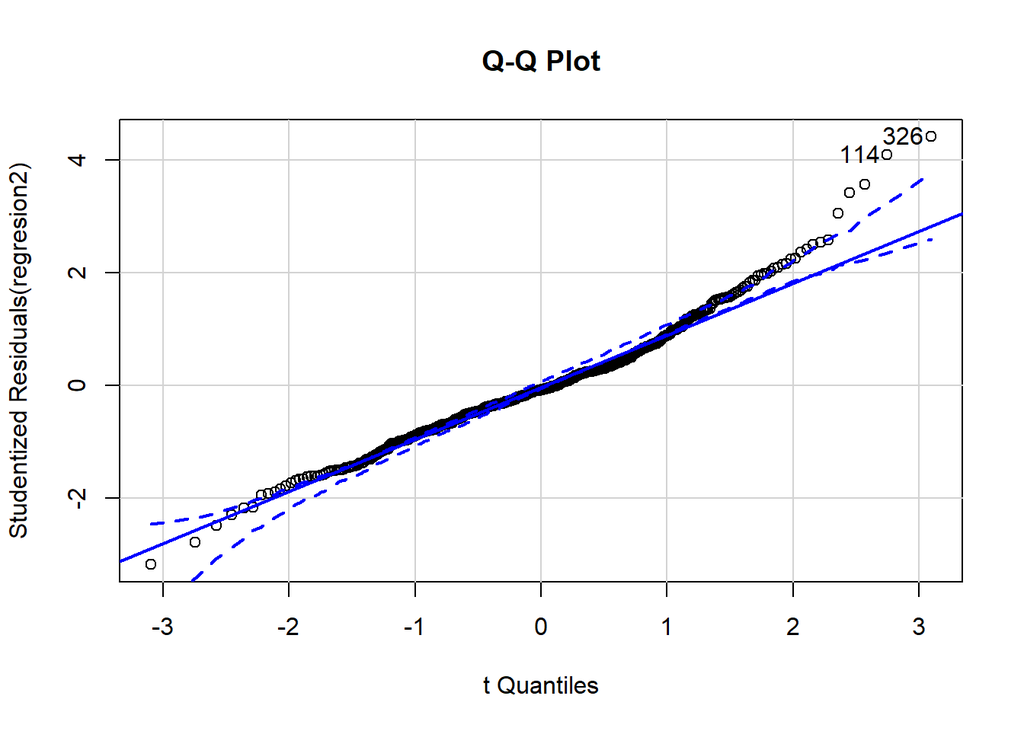

```
## [1] 114 326
```

[figure not shown]

```r
qqPlot(regresion2, labels=row.names(NBA_dataset), id.method="identify",
       simulate=TRUE, main="Q-Q Plot") ## Una forma de ver de manera gráfica que no se cumple la normalidad con Q-Q plot
```

Observamos que los valores se sitúan en torno a la media y que tenemos valores atípicos, adicionalmente, se observa de una forma clara que nuestro conjunto de datos no sigue una distribución normal.

- Para el caso de la linealidad

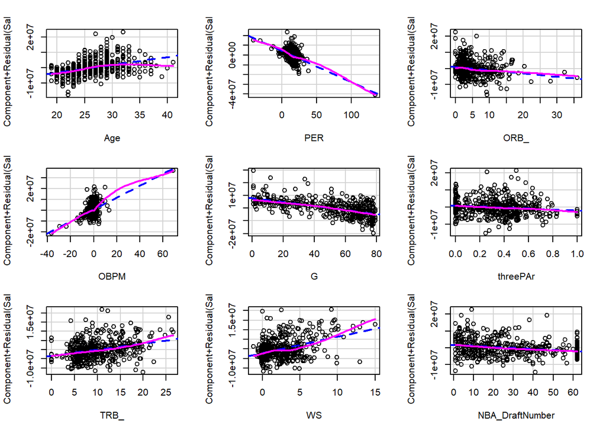

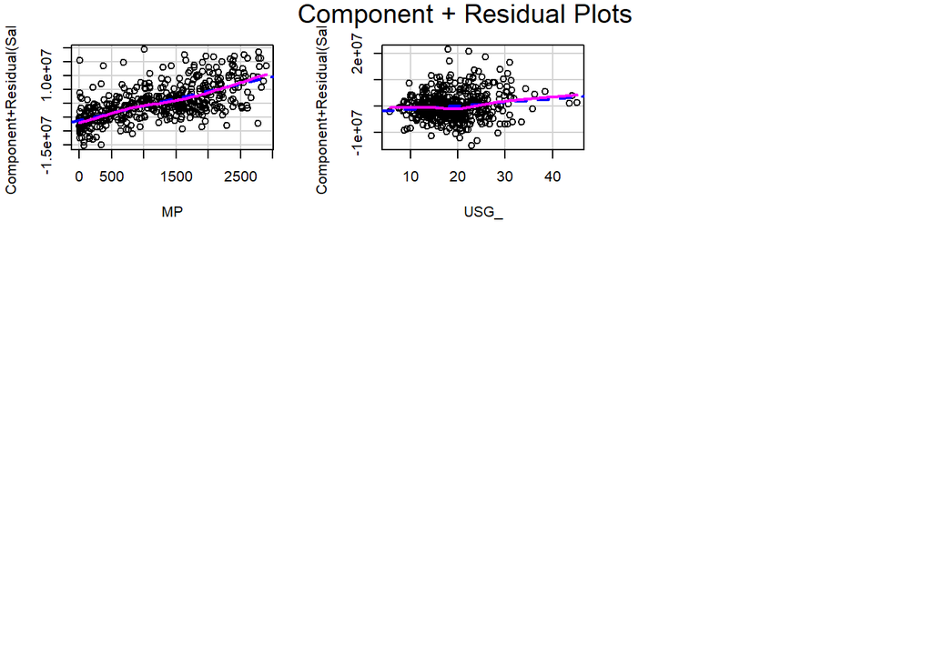

- Para la homocestacidad

```
## Non-constant Variance Score Test
## Variance formula: ~ fitted.values
## Chisquare = 93.04367, Df = 1, p = < 2.22e-16
```

Con que p-valor es menor a 0.05 rechazamos la hipótesis de homocedasticidad.

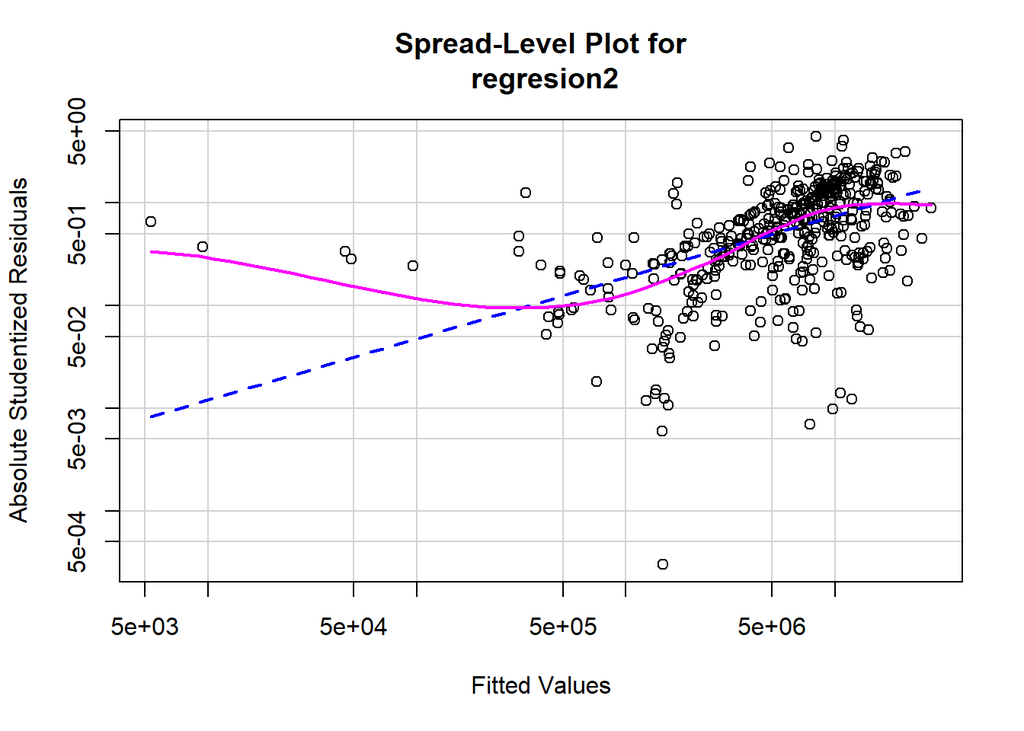

```
##
## Suggested power transformation:  0.4014307
```

Comprobamos gráficamente que no la hay.

- Vamos a observar si hay problemas de multcolinealidad

```
##             Age             PER            ORB_            STL_             OWS
##           FALSE            TRUE            TRUE           FALSE            TRUE
##            OBPM             TS_            DRB_            BLK_             DWS
##            TRUE            TRUE            TRUE            TRUE            TRUE
##            DBPM               G        threePAr            TRB_            TOV_
##            TRUE            TRUE            TRUE            TRUE           FALSE
##              WS             BPM NBA_DraftNumber              MP             FTr
##            TRUE            TRUE           FALSE            TRUE           FALSE
##            AST_            USG_           WS_48            VORP
##           FALSE            TRUE            TRUE            TRUE
```

Observamos que hay problemas de multicolinealidad, porque hay varios variables en donde **el vif es mayor que 2**.

- Miramos gráficamente los valores atípicos.

```
##     rstudent unadjusted p-value Bonferroni p
## 326 4.418019         1.2388e-05    0.0059588
## 114 4.097004         4.9325e-05    0.0237250
```

- Gráfico de influencias

Para observar los *puntos influyentes* y *los valores atípicos*. *El tamaño de los círculos nos indica cuán influyentes son nuestros puntos.*

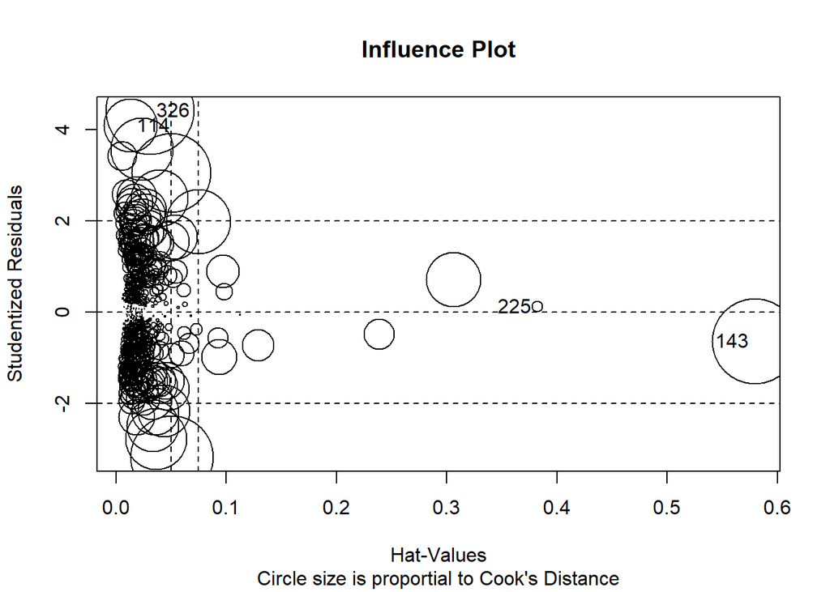

```
##        StudRes        Hat        CookD
## 114  4.0970044 0.01335831 0.0183217443
## 143 -0.6387408 0.57925981 0.0468679555
## 225  0.1211155 0.38197382 0.0007571094
## 326  4.4180190 0.03106963 0.0501763187
```

El 143 a priori es una observación influyente.

# Importancia relativa de las variables

*Para conocer los pesos de cada uno de las variables en el modelo*

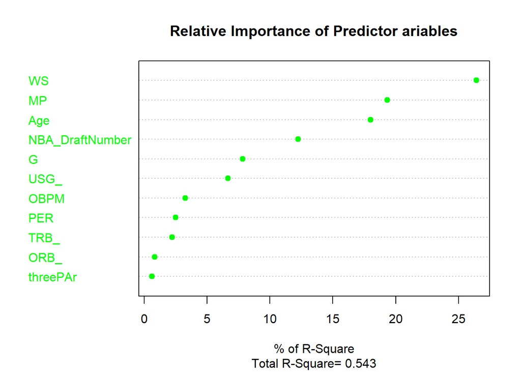

```
##                    Weights
## threePAr         0.6091415
## ORB_             0.8426545
## TRB_             2.2368562
## PER              2.5104005
## OBPM             3.2774649
## USG_             6.6742203
## G                7.8423530
## NBA_DraftNumber 12.2338554
## Age             18.0024613
## MP              19.3329810
## WS              26.4376113
```

Observamos que las variables que más peso tienen son la WS, los minutos jugados y la edad del jugador.

# Hacemos el modelo de predicción

- Realizamos una muestra de n = 10 sobre la base de datos

*Observamos el salario de cada jugador que nos ayudará a comparar los valores que nos salen en nuestra predicción.*

```
## [1] 483
```

```
## # A tibble: 10 x 28
##    Player Salary NBA_Country NBA_DraftNumber   Age Tm        G    MP   PER   TS_
##    <chr>   <dbl> <chr>                 <dbl> <dbl> <chr> <dbl> <dbl> <dbl> <dbl>
##  1 Jason~ 5.22e6 USA                      20    31 WAS      31   276   8.2 0.444
##  2 Gary ~ 2.55e6 USA                      19    23 DEN      65  2265  16.6 0.599
##  3 D'Ang~ 5.56e6 USA                       2    21 BRK      44  1124  15.5 0.506
##  4 Richa~ 1.47e6 USA                      37    24 PHI      44   668  16.8 0.566
##  5 Quinc~ 3.85e6 USA                      26    29 CHI      23   196   4   0.398
##  6 Davis~ 1.31e6 Latvia                   42    25 SAS      74  1067  14.2 0.587
##  7 Nikol~ 1.47e6 Serbia                   41    22 DEN      71  2288  24.4 0.607
##  8 Chris~ 2.46e7 USA                       4    32 HOU      55  1753  24.3 0.601
##  9 Dario~ 2.42e6 Croatia                  12    23 PHI      74  2229  16.1 0.587
## 10 DeAnd~ 1.58e6 USA                      53    29 TOT      55   711   6.2 0.485
## # ... with 18 more variables: threePAr <dbl>, FTr <dbl>, ORB_ <dbl>,
## #   DRB_ <dbl>, TRB_ <dbl>, AST_ <dbl>, STL_ <dbl>, BLK_ <dbl>, TOV_ <dbl>,
## #   USG_ <dbl>, OWS <dbl>, DWS <dbl>, WS <dbl>, WS_48 <dbl>, OBPM <dbl>,
## #   DBPM <dbl>, BPM <dbl>, VORP <dbl>
```

- Hacemos la predicción con tamaño muestral de 10 individuos.

```
##          1          2          3          4          5          6          7
##  5812043.7 11205194.1  6446277.3  4114492.8  4110509.4  1253707.1 15201985.8
##          8          9         10
## 20748503.2 12199777.0   601566.5
```

Tenemos predicho pues el salario para cada uno de estos jugadores. Con algunos casos, se observa que el salario más o menos se ajusta al salario propuesto por la base de datos, mientras que, en otros muchos casos, vemos como según nuestro modelo de predicción el jugador en cuestión se encuentra infravalorado y debería de cobrar más.